# Forecasting on Visitor data for USA

Loading Libraries and Data:

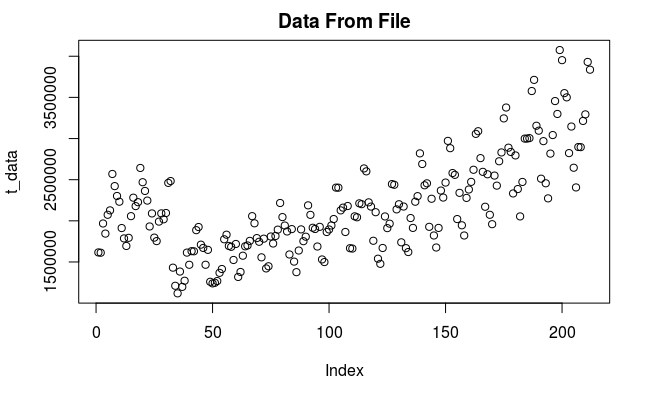

```r
library("ggplot2")
library(readr)
library(forecast)
F <- read.csv("Final_Travel.csv")
t_data <- F$Value
plot(t_data, main = "Data From File")
```

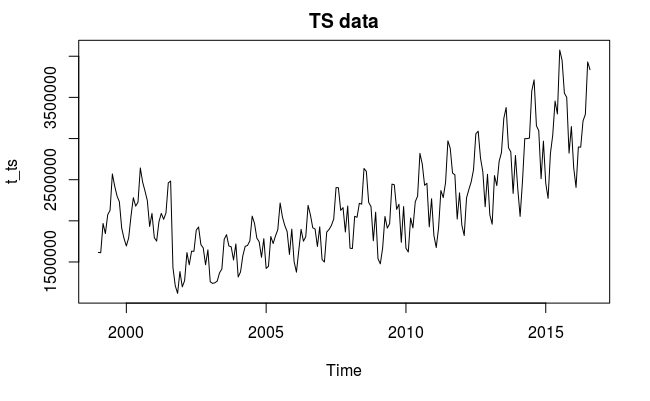

```r
t_ts <- ts(t_data,start=c(1999,1),frequency = 12)
plot(t_ts, main = "TS data")
```

```r
t_ts <-window(t_ts, c(2001,9),c(2015,12),frequency= 12 )
```

Plotting and Inference:

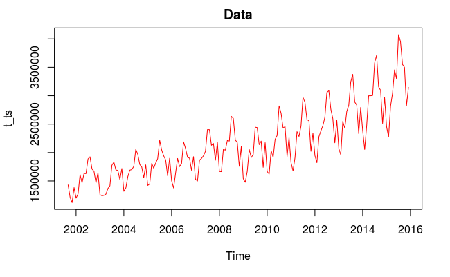

```r
plot(t_ts,col = 'RED', main = "Data")
```

From the plot we can see presence of trend and seasonality

Central Tendency:

```r
summary(t_ts)
```

```
   Min. 1st Qu.  Median    Mean 3rd Qu.    Max.
1119000 1694000 2028000 2141000 2467000 4075000
```

From summary we can observe that mean is not equal to median

Boxplot:

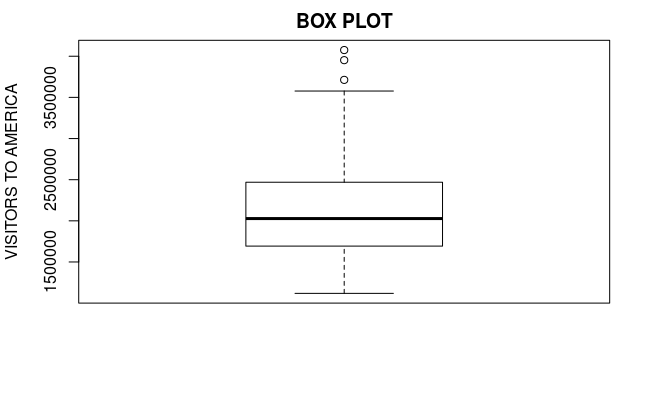

```r
t_box <- boxplot(t_ts, ylab = "VISITORS TO AMERICA", main="BOX PLOT")
```

From box plot we can observe: (1) Right skewness in data (2) Presence of outliers in plot can be seen

Decomposition:

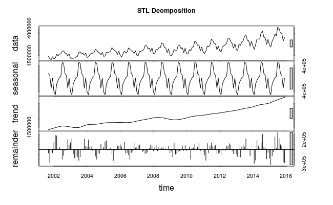

```r
stl_d <- stl(t_ts,s.window ="periodic")
plot(stl_d, main = "STL Deomposition")
```

```r
stl_d
```

```
 Call:
 stl(x = t_ts, s.window = "periodic")

Components
           seasonal   trend    remainder
Sep 2001  160981.18 1343166  -73230.3829
Oct 2001  101926.79 1371489 -262631.4515
Nov 2001 -282527.53 1399811    1513.4115
Dec 2001   23956.26 1424849  -65154.3220
Jan 2002 -397667.14 1449887  145177.1250
Feb 2002 -483992.21 1474029  282085.5681
Mar 2002 -155096.89 1498170  270791.6232
Apr 2002  -49834.86 1523846   -7962.9891
May 2002   34427.14 1549521   47265.4292
Jun 2002   75273.80 1563862   -9372.0431
Jul 2002  504430.31 1578203 -196092.3645
Aug 2002  468123.21 1575505 -118738.4319
Sep 2002  160981.18 1572807  -23266.5642
Oct 2002  101926.79 1561381    7528.5656
Nov 2002 -282527.53 1549954  198793.6272
Dec 2002   23956.26 1535220   88111.3772
Jan 2003 -397667.14 1520487  136558.3076
Feb 2003 -483992.21 1506292  217606.3499
Mar 2003 -155096.89 1492097  -89950.9959
Apr 2003  -49834.86 1484316 -166427.3267
May 2003   34427.14 1476535 -143108.6268
Jun 2003   75273.80 1481984 -142830.1211
Jul 2003  504430.31 1487433 -215966.4645
Aug 2003  468123.21 1510498 -147139.6834
Sep 2003  160981.18 1533564     253.0327
Oct 2003  101926.79 1568224   14022.0552
Nov 2003 -282527.53 1602885  204019.0094
Dec 2003   23956.26 1631634   63227.2562
Jan 2004 -397667.14 1660384   55353.6834
Feb 2004 -483992.21 1672270  190115.4032
Mar 2004 -155096.89 1684155   47013.7350
Apr 2004  -49834.86 1684490   55665.7470
May 2004   34427.14 1684825  -18664.2103
Jun 2004   75273.80 1686001   -4742.0350
Jul 2004  504430.31 1687177 -134653.7087
```

[output cut: 122 more lines]

```
Oct 2014  101926.79 2969745   23950.5971
Nov 2014 -282527.53 2982226 -187507.8923
Dec 2014   23956.26 3004776  -60417.3159
Jan 2015 -397667.14 3027326 -173329.5592
Feb 2015 -483992.21 3062715 -305795.9414
Mar 2015 -155096.89 3098105 -126031.7118
Apr 2015  -49834.86 3133736  -41558.4825
May 2015   34427.14 3169368  251665.7774
Jun 2015   75273.80 3200263   23180.4744
Jul 2015  504430.31 3231157  339796.3224
Aug 2015  468123.21 3263649  220786.5659
Sep 2015  160981.18 3296141   94710.7445
Oct 2015  101926.79 3327299   71284.2034
Nov 2015 -282527.53 3358457 -252939.4059
Dec 2015   23956.26 3386651 -264704.3745
```

Time series data looks seasonal

```r
decomp_t <- decompose(t_ts)
decomp_t$type
```

```
[1] "additive"
```

So we can see that: (1) Decomposition is additive (2) Seasonality component has reamained the same over years, indicating additive property (3) Trend is visible, with few increase and drops (4) Also high remained values can be observed

```r
attributes(decomp_t)
```

```
$names
[1] "x"        "seasonal" "trend"    "random"   "figure"   "type"

$class
[1] "decomposed.ts"
```

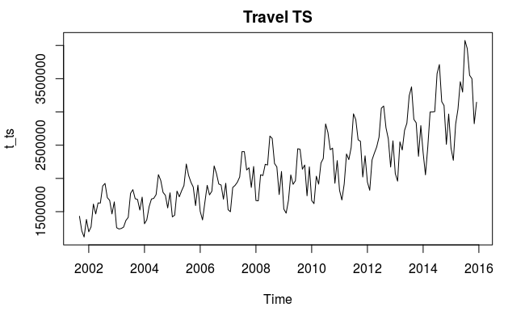

```r
plot(t_ts, main = "Travel TS")
```

```r
max(t_ts)
```

```
[1] 4075384
```

```r
min(t_ts)
```

```
[1] 1118797
```

```r
t_ts
```

```
         Jan     Feb     Mar     Apr     May     Jun     Jul     Aug     Sep     Oct     Nov     Dec
2001                                                                 1430917 1210784 1118797 1383651
2002 1197397 1272122 1613865 1466048 1631214 1629764 1886541 1924890 1710522 1670836 1466220 1647288
2003 1259378 1239906 1247049 1268054 1367854 1414428 1775897 1831482 1694798 1684173 1524376 1718818
2004 1318071 1378393 1576072 1690321 1700588 1756533 2056954 1969876 1790264 1745540 1556348 1783297
2005 1421543 1447900 1809585 1724361 1815562 1893062 2216786 2045389 1942971 1870696 1591261 1899412
2006 1504459 1376271 1639161 1895999 1752524 1807400 2188146 2072655 1915993 1900634 1687972 1927076
2007 1530596 1498808 1864009 1895069 1943625 2021723 2403643 2402926 2127059 2160422 1864426 2179971
2008 1667306 1663065 2054590 2043120 2212729 2202405 2636697 2601265 2224572 2173125 1757800 2104777
2009 1539857 1477601 1670120 2053246 1911411 1965630 2446500 2438329 2139208 2201623 1738986 2173673
2010 1667830 1620897 2033811 1914155 2232171 2300022 2819980 2690559 2431989 2455718 1927225 2268259
2011 1821897 1675937 1913916 2367951 2282842 2465001 2971634 2882766 2580758 2558899 2021408 2340148
2012 1945853 1821812 2278599 2380707 2473500 2620500 3056930 3089122 2761914 2595350 2171127 2565624
2013 2073430 1959241 2549854 2427711 2723745 2831315 3244684 3376837 2888965 2837222 2332842 2794796
2014 2386130 2053750 2472663 2999319 2999313 3005146 3577316 3712864 3155578 3095622 2512191 2968315
2015 2456329 2272927 2816976 3042343 3455461 3298717 4075384 3952559 3551833 3500510 2822990 3145903
```

Here we observe that: (1) Peak value is in July 2015 (2) Lowest value is in November 2001 (3) Number of visitor is less in January, this may be because of Winter weather

```r
plot(t_ts, main = "Travel TS")
seasadj(stl_d)
```

```
         Jan     Feb     Mar     Apr     May     Jun     Jul     Aug     Sep     Oct     Nov     Dec
2001                                                                 1269936 1108857 1401325 1359695
2002 1595064 1756114 1768962 1515883 1596787 1554490 1382111 1456767 1549541 1568909 1748748 1623332
2003 1657045 1723898 1402146 1317889 1333427 1339154 1271467 1363359 1533817 1582246 1806904 1694862
2004 1715738 1862385 1731169 1740156 1666161 1681259 1552524 1501753 1629283 1643613 1838876 1759341
2005 1819210 1931892 1964682 1774196 1781135 1817788 1712356 1577266 1781990 1768769 1873789 1875456
2006 1902126 1860263 1794258 1945834 1718097 1732126 1683716 1604532 1755012 1798707 1970500 1903120
2007 1928263 1982800 2019106 1944904 1909198 1946449 1899213 1934803 1966078 2058495 2146954 2156015
2008 2064973 2147057 2209687 2092955 2178302 2127131 2132267 2133142 2063591 2071198 2040328 2080821
2009 1937524 1961593 1825217 2103081 1876984 1890356 1942070 1970206 1978227 2099696 2021514 2149717
2010 2065497 2104889 2188908 1963990 2197744 2224748 2315550 2222436 2271008 2353791 2209753 2244303
2011 2219564 2159929 2069013 2417786 2248415 2389727 2467204 2414643 2419777 2456972 2303936 2316192
2012 2343520 2305804 2433696 2430542 2439073 2545226 2552500 2620999 2600933 2493423 2453655 2541668
2013 2471097 2443233 2704951 2477546 2689318 2756041 2740254 2908714 2727984 2735295 2615370 2770840
2014 2783797 2537742 2627760 3049154 2964886 2929872 3072886 3244741 2994597 2993695 2794719 2944359
2015 2853996 2756919 2972073 3092178 3421034 3223443 3570954 3484436 3390852 3398583 3105518 3121947
```

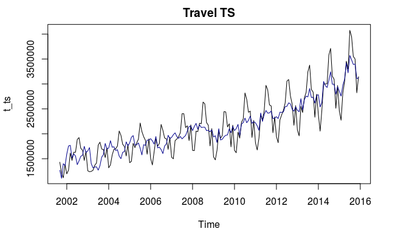

```r
lines(seasadj(stl_d),col ="Darkblue")
```

```r
x <- (seasadj(stl_d))
stl(x, s.window = "periodic")
```

```
 Call:
 stl(x = x, s.window = "periodic")

Components
           seasonal   trend    remainder
Sep 2001 0.00502485 1343166  -73230.3829
Oct 2001 0.00502485 1371489 -262631.4515
Nov 2001 0.00502485 1399811    1513.4115
Dec 2001 0.00502485 1424849  -65154.3220
Jan 2002 0.00502485 1449887  145177.1250
Feb 2002 0.00502485 1474029  282085.5681
Mar 2002 0.00502485 1498170  270791.6232
Apr 2002 0.00502485 1523846   -7962.9891
May 2002 0.00502485 1549521   47265.4292
Jun 2002 0.00502485 1563862   -9372.0431
Jul 2002 0.00502485 1578203 -196092.3645
Aug 2002 0.00502485 1575505 -118738.4319
Sep 2002 0.00502485 1572807  -23266.5642
Oct 2002 0.00502485 1561381    7528.5656
Nov 2002 0.00502485 1549954  198793.6272
Dec 2002 0.00502485 1535220   88111.3772
Jan 2003 0.00502485 1520487  136558.3076
Feb 2003 0.00502485 1506292  217606.3499
Mar 2003 0.00502485 1492097  -89950.9959
Apr 2003 0.00502485 1484316 -166427.3267
May 2003 0.00502485 1476535 -143108.6268
Jun 2003 0.00502485 1481984 -142830.1211
Jul 2003 0.00502485 1487433 -215966.4645
Aug 2003 0.00502485 1510498 -147139.6834
Sep 2003 0.00502485 1533564     253.0327
Oct 2003 0.00502485 1568224   14022.0552
Nov 2003 0.00502485 1602885  204019.0094
Dec 2003 0.00502485 1631634   63227.2562
Jan 2004 0.00502485 1660384   55353.6834
Feb 2004 0.00502485 1672270  190115.4032
Mar 2004 0.00502485 1684155   47013.7350
Apr 2004 0.00502485 1684490   55665.7470
May 2004 0.00502485 1684825  -18664.2103
Jun 2004 0.00502485 1686001   -4742.0350
Jul 2004 0.00502485 1687177 -134653.7087
```

[output cut: 122 more lines]

```
Oct 2014 0.00502485 2969745   23950.5971
Nov 2014 0.00502485 2982226 -187507.8923
Dec 2014 0.00502485 3004776  -60417.3159
Jan 2015 0.00502485 3027326 -173329.5592
Feb 2015 0.00502485 3062715 -305795.9414
Mar 2015 0.00502485 3098105 -126031.7118
Apr 2015 0.00502485 3133736  -41558.4825
May 2015 0.00502485 3169368  251665.7774
Jun 2015 0.00502485 3200263   23180.4744
Jul 2015 0.00502485 3231157  339796.3224
Aug 2015 0.00502485 3263649  220786.5659
Sep 2015 0.00502485 3296141   94710.7445
Oct 2015 0.00502485 3327299   71284.2034
Nov 2015 0.00502485 3358457 -252939.4059
Dec 2015 0.00502485 3386651 -264704.3745
```